# Adjusting ND energies.

Hitherto, peak ND energies (peak $E$s) were used as the data points in the correlation test with experimental folding rate. The results show promise for two-state folders --a significant ($\alpha$ = 0.05) Pearson correlation with coefficient around -0.7 was achieved--, but less so for multi-state folders --a significant Pearson correlation with coefficient around -0.5 was achieved only after excluding an outlier.

In this notebook, we explore how much these results can be improved by selecting different data points from the choices presented by a ND variant, using a linear regression model. The regression function's main role here is to assist in the adjustment of ND energy data points to improve correlation with experimental folding rate.

- The idea is better ND variants require fewer adjustments to achieve stronger correlations.

Adjust Method:

- Obtain $\hat Y = a X + b$, the regression function relating peak ND energies ($X$) with fold rates ($Y$) for a set of pids (train set).
- For each pid, obtain a "new" ND energy point from the ND energy values generated at peak $Q$ that will maximize the linear relationship between ND energy and fold rate.
  - Let $E_{peakQ}$ be the ND energies at peak $Q$. For each $x \in E_{peakQ}$, evaluate $\hat y = ax + b$, and find the $x$ that minimizes the difference between $\hat y$ and the fold rate $y$.
- For each "new" ND energy point, find the ND energy Gaussian that maximizes its likelihood, and assign this $Q$ as the "new peak" $Q$ for a pid.
  - Sample space for $Q$ is set as wide as reasonable to $[0.1, 0.9]$.
  - We are interested in which $Q$ the method will choose, particularly for multi-state pids. Will they stay within the ND-TS region ($Q < 0.5$)? This depends on how the ND energy Gaussians overlap.
- The means of the ND energy Gaussians associated with the "new peak" $Q$s are the "adjusted" ND energies ($\tilde X$).
- Obtain a new regression function based on the "adjusted" ND energies: $\hat Y = a \tilde X + b$.

```python
import os
import numpy as np
import pandas as pd
from scipy.stats import pearsonr, norm
import matplotlib.pyplot as plt
from sklearn import linear_model
import NDutils as nd # my lib
```

```python
# constrain the candidate Es to those associated with peak Q
# shift in Q affected by considerable overlapping Gaussians
# new E is the mean of the Gaussian at new Q
def adjust1(reg, pids, y, peakEs, peakQs, ndstats: dict, nd_Eparams: dict, \
            min_Q=0.1, max_Q=0.9):
    """Does one round of adjustments."""
    a = nd.Qs.index(min_Q); b = nd.Qs.index(max_Q)
    new_Es = peakEs.copy(); new_Qs = peakQs.copy()
    num_changes = 0
    for i, pid in enumerate(pids):
        peak_q = peakQs[i] # peak Q for a pid
        Es = ndstats[pid].loc[peak_q].sc_mje.values # E values associated with peak E Gaussian
        pred_y = reg.predict(Es.reshape(-1,1))
        j = np.argmin(np.abs(pred_y - y[i])) # get the index of the smallest residual
        new_E = Es[j]; # x that produces the smallest residual
        # find Q that most likely generates new_E
        q_params = [ nd_Eparams[pid, q] for q in nd.Qs[a : b+1] ]
        dens = [norm.pdf(new_E, m, s) for m, s in q_params] # Gaussian density of x at each q
        new_Q = nd.Qs[np.argmax(dens) + a]
        if new_Q != peak_q:
            new_Qs[i] = new_Q
            new_Es[i] = nd_Eparams[pid, new_Q][0] # take the mean of the Gaussian at new_Q
            num_changes += 1
    return new_Qs, new_Es, num_changes
```

```python
def print_stats(Qs: list, Es: list, frates: np.array, peakQs: list):
    print("Q stats:", np.round(np.mean(Qs), 4), np.round(np.std(Qs), 4), \
          np.min(Qs), np.max(Qs), np.sum(np.array(Qs) > 0.5))
    print("MAD from peak Qs:", np.mean(np.abs(np.array(peakQs) - np.array(Qs))))
    print("E range:", np.round(nd.mjes_range(Es), 4))
    x = np.array(Es)
    print("Corr with exp. fold rate:", np.round(pearsonr(x, frates), 4))
    y_true = frates.reshape(-1, 1)
    reg.fit(x.reshape(-1,1), y_true)
    y_pred = reg.predict(x.reshape(-1,1))
    print("MSE, R2, adj_R2:", np.round(nd.mra(y_true, y_pred), 4)) # mse, r2, adj_r2
    print("predicted range:", np.ptp(y_true), np.round(np.ptp(y_pred), 4))
    return y_pred
```

### Uzunoglo

```python
fn = os.path.join('UZ_c', 'UZ_frates.txt')
df = nd.load_frates(fn)
PIDs = df.pid.tolist()
fold_rates = df.k_f.values
print(len(PIDs))
print("Range of fold rates:", np.ptp(fold_rates))
y_true = fold_rates.reshape(-1, 1)
reg = linear_model.LinearRegression()
```

```
52
Range of fold rates: 5.96
```

```python
# load stats for the three ND variants
c_ndstats = nd.get_NDstats('UZ_c', PIDs, 'c')
x_ndstats = nd.get_NDstats('UZ_x', PIDs, 'x')
r_ndstats = nd.get_NDstats('UZ_r', PIDs, 'r')
```

#### 'c' ND variant

```python
c_mje_params = nd.get_params(c_ndstats, 'sc_mje')
c_peakQs, c_peakEs = nd.get_peaks(c_mje_params, PIDs)
print("'c' peak (unadjusted).")
peak_c_y_pred = print_stats(c_peakQs, c_peakEs, fold_rates, c_peakQs)
```

```
'c' peak (unadjusted).
Q stats: 0.2442 0.0718 0.1 0.4 0
MAD from peak Qs: 0.0
E range: 4.3814
Corr with exp. fold rate: [-0.7145  0.    ]
MSE, R2, adj_R2: [0.9853 0.5104 0.4905]
predicted range: 5.96 4.758
```

```python
c_newQs, c_newEs, num_changes = adjust1(reg, PIDs, y_true, c_peakEs, c_peakQs,\
                                      c_ndstats, c_mje_params)
print("'c' new (adjusted). ", num_changes)
new_c_y_pred = print_stats(c_newQs, c_newEs, fold_rates, c_peakQs)
```

```
'c' new (adjusted).  31
Q stats: 0.2269 0.136 0.1 0.6 3
MAD from peak Qs: 0.09807692307692308
E range: 4.3985
Corr with exp. fold rate: [-0.8935  0.    ]
MSE, R2, adj_R2: [0.4059 0.7983 0.7901]
predicted range: 5.96 6.0148
```

#### 'x' ND variant

```python
x_mje_params = nd.get_params(x_ndstats, 'sc_mje')
x_peakQs, x_peakEs = nd.get_peaks(x_mje_params, PIDs)
print("'x' peak (unadjusted).")
peak_x_y_pred = print_stats(x_peakQs, x_peakEs, fold_rates, x_peakQs)
```

```
'x' peak (unadjusted).
Q stats: 0.2577 0.0716 0.1 0.4 0
MAD from peak Qs: 0.0
E range: 4.2422
Corr with exp. fold rate: [-0.7048  0.    ]
MSE, R2, adj_R2: [1.0129 0.4967 0.4762]
predicted range: 5.96 4.5231
```

```python
x_newQs, x_newEs, num_changes = adjust1(reg, PIDs, y_true, x_peakEs, x_peakQs,\
                                      x_ndstats, x_mje_params)
print("'x' new (adjusted). ", num_changes)
new_x_y_pred = print_stats(x_newQs, x_newEs, fold_rates, x_peakQs)
```

```
'x' new (adjusted).  27
Q stats: 0.2423 0.1306 0.1 0.6 3
MAD from peak Qs: 0.08846153846153845
E range: 4.2227
Corr with exp. fold rate: [-0.9109  0.    ]
MSE, R2, adj_R2: [0.3427 0.8297 0.8228]
predicted range: 5.96 5.5904
```

#### 'r' ND variant

```python
r_mje_params = nd.get_params(r_ndstats, 'sc_mje')
r_peakQs, r_peakEs = nd.get_peaks(r_mje_params, PIDs)
print("'r' peak (unadjusted).")
peak_r_y_pred = print_stats(r_peakQs, r_peakEs, fold_rates, r_peakQs)
```

```
'r' peak (unadjusted).
Q stats: 0.1596 0.0491 0.1 0.2 0
MAD from peak Qs: 0.0
E range: 1.9358
Corr with exp. fold rate: [-0.2101  0.135 ]
MSE, R2, adj_R2: [1.9238 0.0441 0.0051]
predicted range: 5.96 1.4201
```

```python
r_newQs, r_newEs, num_changes = adjust1(reg, PIDs, y_true, r_peakEs, r_peakQs,\
                                      r_ndstats, r_mje_params)
print("'r' new (adjusted). ", num_changes)
new_r_y_pred = print_stats(r_newQs, r_newEs, fold_rates, r_peakQs)
```

```
'r' new (adjusted).  30
Q stats: 0.2577 0.1182 0.1 0.5 0
MAD from peak Qs: 0.10576923076923078
E range: 4.2256
Corr with exp. fold rate: [-0.7376  0.    ]
MSE, R2, adj_R2: [0.9177 0.544  0.5254]
predicted range: 5.96 4.2997
```

- The new $Q$s mainly stay within the ND-TS region, with a few going as far as $Q = 0.6$.
- After one adjustment round, r2 score improves from about 0.5 to about 0.8 for both 'c' and 'x' ND variants.
- The 'r' ND variant is able to achieve a r2 score of around 0.5, only after one adjustment round.

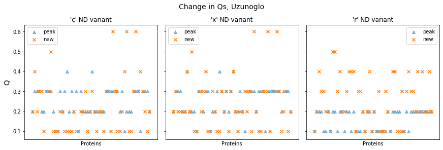

```python
fig, axes = plt.subplots(1, 3, figsize=(12, 4), constrained_layout=True, sharey=True)
plt.suptitle("Change in Qs, Uzunoglo", fontsize=14)

ax = axes[0]
ax.scatter(PIDs, c_peakQs, marker='^', alpha=0.5, label='peak')
ax.scatter(PIDs, c_newQs, marker='x', label="new")
ax.set_title("'c' ND variant")
ax.set_xlabel('Proteins'); ax.set_xticks([])
ax.set_ylabel('Q', fontsize=14); ax.legend()

ax = axes[1]
ax.scatter(PIDs, x_peakQs, marker='^', alpha=0.5, label='peak')
ax.scatter(PIDs, x_newQs, marker='x', label="new")
ax.set_title("'x' ND variant")
ax.set_xlabel('Proteins'); ax.set_xticks([])
ax.legend()

ax = axes[2]
ax.scatter(PIDs, r_peakQs, marker='^', alpha=0.5, label='peak')
ax.scatter(PIDs, r_newQs, marker='x', label="new")
ax.set_title("'r' ND variant")
ax.set_xlabel('Proteins'); ax.set_xticks([])
_ = ax.legend()
```

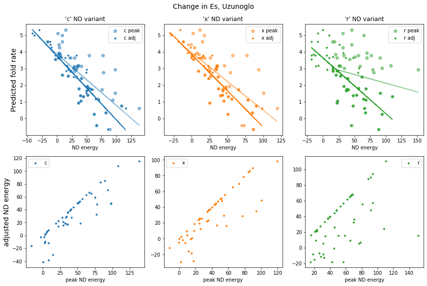

```python
fig, axes = plt.subplots(2, 3, figsize=(12, 8), constrained_layout=True)
fig.suptitle("Change in Es, Uzunoglo", fontsize=14)

ax = axes[0][0]
ax.scatter(c_peakEs, y_true, color='tab:blue', alpha=0.5, label='c peak')
ax.plot(c_peakEs, peak_c_y_pred, color='tab:blue', alpha=0.5)
ax.scatter(c_newEs, y_true, marker='.', color='tab:blue', label='c adj')
ax.plot(c_newEs, new_c_y_pred, color='tab:blue')
ax.set_title("'c' ND variant"); ax.set_xlabel("ND energy")
ax.set_ylabel("Predicted fold rate", fontsize=14); ax.legend()

ax = axes[0][1]
ax.scatter(x_peakEs, y_true, color='tab:orange', alpha=0.5, label='x peak')
ax.plot(x_peakEs, peak_x_y_pred, color='tab:orange', alpha=0.5)
ax.scatter(x_newEs, y_true, marker='.', color='tab:orange', label='x adj')
ax.plot(x_newEs, new_x_y_pred, color='tab:orange')
ax.set_title("'x' ND variant"); ax.set_xlabel("ND energy"); ax.legend()

ax = axes[0][2]
ax.scatter(r_peakEs, y_true, color='tab:green', alpha=0.5, label='r peak')
ax.plot(r_peakEs, peak_r_y_pred, color='tab:green', alpha=0.5)
ax.scatter(r_newEs, y_true, marker='.', color='tab:green', label='r adj')
ax.plot(r_newEs, new_r_y_pred, color='tab:green')
ax.set_title("'r' ND variant"); ax.set_xlabel("ND energy"); ax.legend()

ax = axes[1][0]
ax.scatter(c_peakEs, c_newEs, marker='.',color='tab:blue', label='c')
ax.set_xlabel('peak ND energy'); ax.legend()
ax.set_ylabel('adjusted ND energy', fontsize=14)

ax = axes[1][1]
ax.scatter(x_peakEs, x_newEs, marker='.',color='tab:orange', label='x')
ax.set_xlabel('peak ND energy'); ax.legend()

ax = axes[1][2]
ax.scatter(r_peakEs, r_newEs, marker='.', color='tab:green', label='r')
ax.set_xlabel('peak ND energy'); _ = ax.legend()
```

### Kamagata

```python
fn = os.path.join('K_c', 'K_frates.txt')
df = nd.load_frates(fn)
PIDs = df.pid.tolist()
fold_rates = df.k_f.values
print(len(PIDs))
print("Range of fold rates:", np.ptp(fold_rates))
y_true = fold_rates.reshape(-1, 1)
reg = linear_model.LinearRegression()
```

```
21
Range of fold rates: 4.55
```

```python
# load stats for the three ND variants
c_ndstats = nd.get_NDstats('K_c', PIDs, 'c')
x_ndstats = nd.get_NDstats('K_x', PIDs, 'x')
r_ndstats = nd.get_NDstats('K_r', PIDs, 'r')
```

#### 'c' ND variant

```python
c_mje_params = nd.get_params(c_ndstats, 'sc_mje')
c_peakQs, c_peakEs = nd.get_peaks(c_mje_params, PIDs)
print("'c' peak (unadjusted).")
peak_c_y_pred = print_stats(c_peakQs, c_peakEs, fold_rates, c_peakQs)
```

```
'c' peak (unadjusted).
Q stats: 0.2524 0.0587 0.2 0.4 0
MAD from peak Qs: 0.0
E range: 4.7971
Corr with exp. fold rate: [-0.384   0.0857]
MSE, R2, adj_R2: [1.0917 0.1475 0.0527]
predicted range: 4.55 2.1069
```

```python
c_newQs, c_newEs, num_changes = adjust1(reg, PIDs, y_true, c_peakEs, c_peakQs,\
                                      c_ndstats, c_mje_params)
print("'c' new (adjusted). ", num_changes)
new_c_y_pred = print_stats(c_newQs, c_newEs, fold_rates, c_peakQs)
```

```
'c' new (adjusted).  14
Q stats: 0.3476 0.1367 0.1 0.6 1
MAD from peak Qs: 0.12380952380952381
E range: 4.6851
Corr with exp. fold rate: [-7.243e-01  2.000e-04]
MSE, R2, adj_R2: [0.6088 0.5246 0.4718]
predicted range: 4.55 3.3635
```

#### 'x' ND variant

```python
x_mje_params = nd.get_params(x_ndstats, 'sc_mje')
x_peakQs, x_peakEs = nd.get_peaks(x_mje_params, PIDs)
print("'x' peak (unadjusted).")
peak_x_y_pred = print_stats(x_peakQs, x_peakEs, fold_rates, x_peakQs)
```

```
'x' peak (unadjusted).
Q stats: 0.3 0.0873 0.1 0.5 0
MAD from peak Qs: 0.0
E range: 4.7393
Corr with exp. fold rate: [-0.3704  0.0984]
MSE, R2, adj_R2: [1.1049 0.1372 0.0413]
predicted range: 4.55 2.0197
```

```python
x_newQs, x_newEs, num_changes = adjust1(reg, PIDs, y_true, x_peakEs, x_peakQs,\
                                      x_ndstats, x_mje_params)
print("'x' new (adjusted). ", num_changes)
new_x_y_pred = print_stats(x_newQs, x_newEs, fold_rates, x_peakQs)
```

```
'x' new (adjusted).  14
Q stats: 0.3143 0.1283 0.1 0.5 0
MAD from peak Qs: 0.11904761904761907
E range: 4.278
Corr with exp. fold rate: [-0.7901  0.    ]
MSE, R2, adj_R2: [0.4813 0.6242 0.5824]
predicted range: 4.55 3.2042
```

#### 'r' ND variant

```python
r_mje_params = nd.get_params(r_ndstats, 'sc_mje')
r_peakQs, r_peakEs = nd.get_peaks(r_mje_params, PIDs)
print("'r' peak (unadjusted).")
peak_r_y_pred = print_stats(r_peakQs, r_peakEs, fold_rates, r_peakQs)
```

```
'r' peak (unadjusted).
Q stats: 0.1667 0.0471 0.1 0.2 0
MAD from peak Qs: 0.0
E range: 2.0637
Corr with exp. fold rate: [-0.2295  0.317 ]
MSE, R2, adj_R2: [ 1.2131  0.0526 -0.0526]
predicted range: 4.55 1.0328
```

```python
r_newQs, r_newEs, num_changes = adjust1(reg, PIDs, y_true, r_peakEs, r_peakQs,\
                                      r_ndstats, r_mje_params)
print("'r' new (adjusted). ", num_changes)
new_r_y_pred = print_stats(r_newQs, r_newEs, fold_rates, r_peakQs)
```

```
'r' new (adjusted).  12
Q stats: 0.2476 0.1096 0.1 0.4 0
MAD from peak Qs: 0.09047619047619047
E range: 4.448
Corr with exp. fold rate: [-0.5548  0.009 ]
MSE, R2, adj_R2: [0.8864 0.3078 0.2309]
predicted range: 4.55 1.8772
```

- The new $Q$s mainly stay within the ND-TS region, with a few going as far as $Q = 0.6$.
- After one adjustment round:
  - Pearson correlation between simulated folding rate (ND energies) and experimental folding rate become significant (pvalue < 0.05) for all three ND variants, with coefficients of around -0.72, -0.79 and -0.55 for 'c', 'x', and 'r', respectively.
  - r2 scores are 0.52, 0.62 and 0.31 for 'c', 'x', and 'r', respectively.

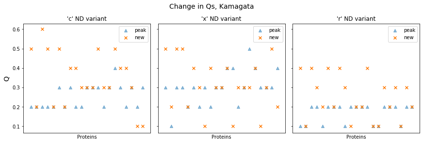

```python
fig, axes = plt.subplots(1, 3, figsize=(12, 4), constrained_layout=True, sharey=True)
plt.suptitle("Change in Qs, Kamagata", fontsize=14)

ax = axes[0]
ax.scatter(PIDs, c_peakQs, marker='^', alpha=0.5, label='peak')
ax.scatter(PIDs, c_newQs, marker='x', label="new")
ax.set_title("'c' ND variant")
ax.set_xlabel('Proteins'); ax.set_xticks([])
ax.set_ylabel('Q', fontsize=14); ax.legend()

ax = axes[1]
ax.scatter(PIDs, x_peakQs, marker='^', alpha=0.5, label='peak')
ax.scatter(PIDs, x_newQs, marker='x', label="new")
ax.set_title("'x' ND variant")
ax.set_xlabel('Proteins'); ax.set_xticks([])
ax.legend()

ax = axes[2]
ax.scatter(PIDs, r_peakQs, marker='^', alpha=0.5, label='peak')
ax.scatter(PIDs, r_newQs, marker='x', label="new")
ax.set_title("'r' ND variant")
ax.set_xlabel('Proteins'); ax.set_xticks([])
_ = ax.legend()
```

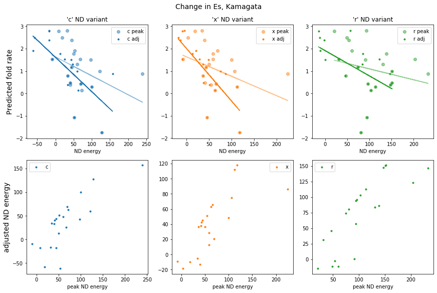

```python
fig, axes = plt.subplots(2, 3, figsize=(12, 8), constrained_layout=True)
fig.suptitle("Change in Es, Kamagata", fontsize=14)

ax = axes[0][0]
ax.scatter(c_peakEs, y_true, color='tab:blue', alpha=0.5, label='c peak')
ax.plot(c_peakEs, peak_c_y_pred, color='tab:blue', alpha=0.5)
ax.scatter(c_newEs, y_true, marker='.', color='tab:blue', label='c adj')
ax.plot(c_newEs, new_c_y_pred, color='tab:blue')
ax.set_title("'c' ND variant"); ax.set_xlabel("ND energy")
ax.set_ylabel("Predicted fold rate", fontsize=14); ax.legend()

ax = axes[0][1]
ax.scatter(x_peakEs, y_true, color='tab:orange', alpha=0.5, label='x peak')
ax.plot(x_peakEs, peak_x_y_pred, color='tab:orange', alpha=0.5)
ax.scatter(x_newEs, y_true, marker='.', color='tab:orange', label='x adj')
ax.plot(x_newEs, new_x_y_pred, color='tab:orange')
ax.set_title("'x' ND variant"); ax.set_xlabel("ND energy"); ax.legend()

ax = axes[0][2]
ax.scatter(r_peakEs, y_true, color='tab:green', alpha=0.5, label='r peak')
ax.plot(r_peakEs, peak_r_y_pred, color='tab:green', alpha=0.5)
ax.scatter(r_newEs, y_true, marker='.', color='tab:green', label='r adj')
ax.plot(r_newEs, new_r_y_pred, color='tab:green')
ax.set_title("'r' ND variant"); ax.set_xlabel("ND energy"); ax.legend()

ax = axes[1][0]
ax.scatter(c_peakEs, c_newEs, marker='.',color='tab:blue', label='c')
ax.set_xlabel('peak ND energy'); ax.legend()
ax.set_ylabel('adjusted ND energy', fontsize=14)

ax = axes[1][1]
ax.scatter(x_peakEs, x_newEs, marker='.',color='tab:orange', label='x')
ax.set_xlabel('peak ND energy'); ax.legend()

ax = axes[1][2]
ax.scatter(r_peakEs, r_newEs, marker='.', color='tab:green', label='r')
ax.set_xlabel('peak ND energy'); _ = ax.legend()
```

## End of notebook

SKLC September 2020